# Week 10: Data Visualisation with `seaborn` - Class Exercises

We first load the packages necessary for this week's exercises.

Let us use `seaborn` for our visualisations.

```python
import numpy as np
import pandas as pd
import matplotlib.pyplot as plt
import seaborn as sns
sns.set_style('darkgrid')
```

# 1. Streaming Services

The file `streamingUS.csv` contains market shares of major streaming service providers in the US between 2020 and 2021.

(a) Read in and prepare the data in tidy format. The first 5 rows should look like this:

|  | order | service | year | share |
| --- | --- | --- | --- | --- |
| 0 | 1 | Netflix | 2020 | 29 |
| 1 | 2 | Prime | 2020 | 21 |
| 2 | 3 | Hulu | 2020 | 16 |
| 3 | 4 | Disney | 2020 | 12 |
| 4 | 5 | Apple | 2020 | 4 |

```python
# Type your code here:
df = pd.read_csv('../data/streamingUS.csv')
df1 = pd.melt(df, id_vars = ['order', 'service'],
              value_vars = ['2020', '2021'],
              var_name = 'year', value_name = 'share')
df1.head()
```

|  | order | service | year | share |
| --- | --- | --- | --- | --- |
| 0 | 1 | Netflix | 2020 | 29 |
| 1 | 2 | Prime | 2020 | 21 |
| 2 | 3 | Hulu | 2020 | 16 |
| 3 | 4 | Disney | 2020 | 12 |
| 4 | 5 | Apple | 2020 | 4 |

(b) Re-create the plot below, as closely as you can.

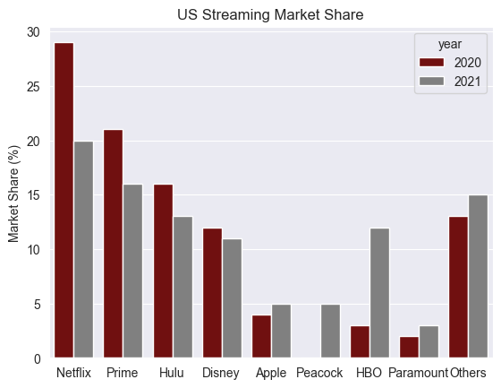

**Hint:**

- Read the documentation for `barplot` here: https://seaborn.pydata.org/generated/seaborn.barplot.html
- The colours are "maroon" and "grey".

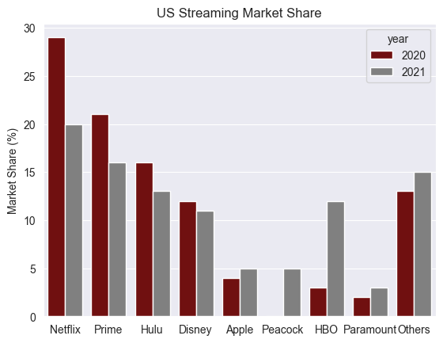

```python
# Type your code here:
ax = sns.barplot(df1, x = 'service', y = 'share', hue = 'year',
                 palette = ['maroon', 'grey'])
ax.set(title = 'US Streaming Market Share', ylabel = 'Market Share (%)', xlabel = '')
plt.show()
```

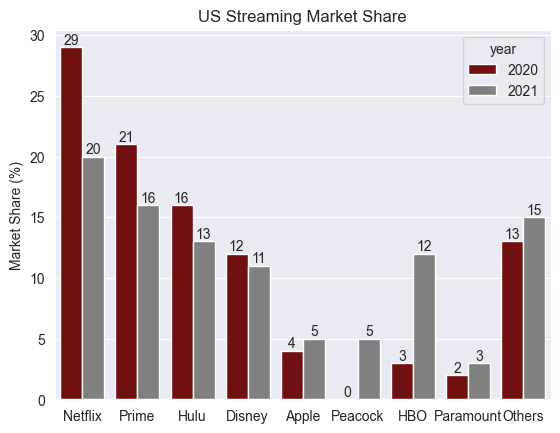

```python
# EXTRA
# we can display the market share value at the top edge of each bar.
ax = sns.barplot(df1, x = 'service', y = 'share', hue = 'year',
                 palette = ['maroon', 'grey'])
ax.set(title = 'US Streaming Market Share', ylabel = 'Market Share (%)', xlabel = '')

# each bar in the plot belongs to a container
# read https://seaborn.pydata.org/generated/seaborn.barplot.html
for container in ax.containers:
    ax.bar_label(container)
plt.show()
```

(c) Compute the year-on-year growth in market share for each service provider.  
Create a `growth` column to record the percentage change in share, and a `type` column with two possible values: `Loss` for negative growth, and `Gain` for positive growth.  
The first few rows should look like this:

|  | order | service | year | share | growth | type |
| --- | --- | --- | --- | --- | --- | --- |
| 0 | 1 | Netflix | 2021 | 20 | -9.0 | Loss |
| 1 | 2 | Prime | 2021 | 16 | -5.0 | Loss |
| 2 | 3 | Hulu | 2021 | 13 | -3.0 | Loss |
| 3 | 4 | Disney | 2021 | 11 | -1.0 | Loss |
| 4 | 5 | Apple | 2021 | 5 | 1.0 | Gain |

**Hint:**  
Read the documentation for the `diff` function here: https://pandas.pydata.org/docs/reference/api/pandas.DataFrame.diff.html

```python
# Type your code here:
df1['growth'] = df1.sort_values('year').groupby('service')['share'].diff()
df1['type'] = np.where(df1['growth'] >= 0, 'Gain', 'Loss')
growth = df1.dropna(subset = ['growth']).copy()
growth = growth.sort_values('growth', ascending = True).reset_index(drop = True)
growth.head()
```

|  | order | service | year | share | growth | type |
| --- | --- | --- | --- | --- | --- | --- |
| 0 | 1 | Netflix | 2021 | 20 | -9.0 | Loss |
| 1 | 2 | Prime | 2021 | 16 | -5.0 | Loss |
| 2 | 3 | Hulu | 2021 | 13 | -3.0 | Loss |
| 3 | 4 | Disney | 2021 | 11 | -1.0 | Loss |
| 4 | 5 | Apple | 2021 | 5 | 1.0 | Gain |

(d) Using the table above, recreate the following graph, as closely as you can.

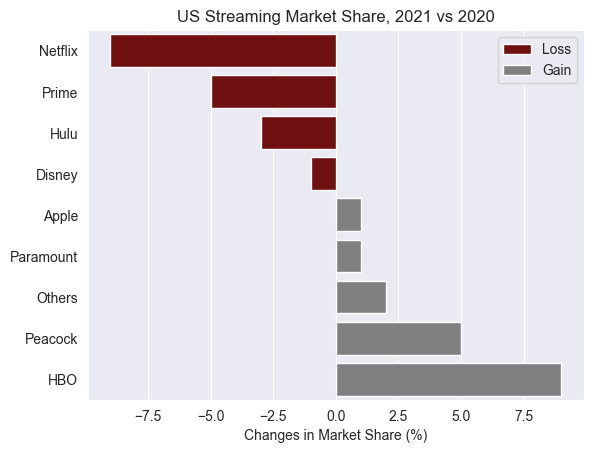

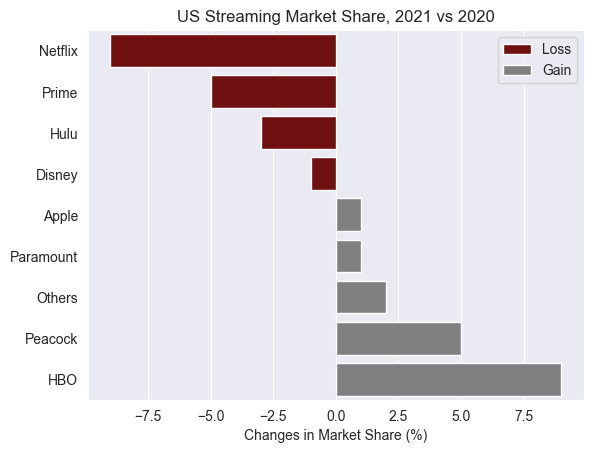

```python
# Type your code here:
ax = sns.barplot(growth, x = 'growth', y = 'service', hue = 'type',
                 palette = ['maroon', 'gray'])
ax.set(title = 'US Streaming Market Share, 2021 vs 2020',
       xlabel = 'Changes in Market Share (%)', ylabel = '')
plt.legend(title = '')
plt.show()
```

# 2. Human Development Index

The UN’s Human Development Index (HDI) is a composite measure that reflects a country’s performance in three aspects: health, education, and wealth.

It ranges from 0 to 1 --- a value closer to 1 indicates that the country offers generally decent healthcare, education, and standard of living.

The file `UN_HDI_2021.xlsx` contains the HDI scores for 191 countries in 1990 and 2021.  
The file also contains a spreadsheet that groups the countries into broad geographical regions in the world.

(a) Read in the data and re-create, as much as you can, the following heatmap, which shows how HDI has changed for Indonesia, Malaysia and Singapore between 1990 and 2021.

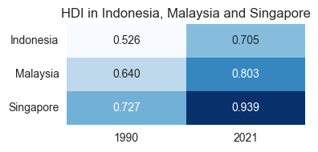

**Hint:**  
Read the documentation for `heatmap` here: https://seaborn.pydata.org/generated/seaborn.heatmap.html

```
            1990   2021
Country
Indonesia  0.526  0.705
Malaysia   0.640  0.803
Singapore  0.727  0.939
```

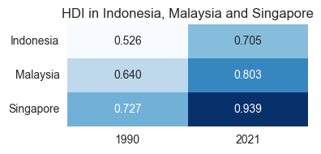

```python
# Type your code here:
hdi = pd.read_excel('../data/UN_HDI_2021.xlsx', sheet_name = 'Sheet1',
                    skiprows = 4, na_values = '..')
hdi_sg_my = hdi[hdi['Country'].isin(['Singapore', 'Indonesia', 'Malaysia'])].copy().sort_values('Country').set_index('Country')
hdi_sg_my[1990] = pd.to_numeric(hdi_sg_my[1990])
hdi_sg_my[2021] = pd.to_numeric(hdi_sg_my[2021])
print(hdi_sg_my.head())

fig, ax = plt.subplots(figsize = (4, 2))
sns.heatmap(hdi_sg_my, annot = True,
            cmap = 'Blues', cbar = False, fmt = '.3f')
ax.set(title = 'HDI in Indonesia, Malaysia and Singapore',
       xlabel = '', ylabel = '')
ax.set_yticklabels(ax.get_yticklabels(), rotation = 0)
fig.tight_layout()
plt.show()
```

(b) We next explore the changes in HDI between 1990 and 2021 for all countries in the data across five regions of Africa, Americas, Asia, Europe and Oceania.

To do that, first prepare the HDI data above in tidy format, and "join" it with the information given in `Sheet 2` to include a `Region.Name` column.  
The tidy table should look like this:

|  | Country | year | hdi | iso3 | Region.Name |
| --- | --- | --- | --- | --- | --- |
| 0 | Switzerland | 1990 | 0.851 | CHE | Europe |
| 1 | Norway | 1990 | 0.838 | NOR | Europe |
| 2 | Iceland | 1990 | 0.811 | ISL | Europe |
| 3 | Hong Kong, China (SAR) | 1990 | 0.788 | HKG | Asia |
| 4 | Australia | 1990 | 0.865 | AUS | Oceania |

```python
# Type your code here:
hdi_long = (
            hdi.melt(
                    id_vars='Country', value_vars = [1990, 2021],
                    var_name = 'year', value_name = 'hdi'
                    ).dropna()
            )

regions = pd.read_excel('../data/UN_HDI_2021.xlsx', sheet_name = 'Sheet2')
hdi_regions = hdi_long.merge(regions, left_on = 'Country', right_on = 'country', how = 'left').drop(columns=['country'])
hdi_regions.head()
```

|  | Country | year | hdi | iso3 | Region.Name |
| --- | --- | --- | --- | --- | --- |
| 0 | Switzerland | 1990 | 0.851 | CHE | Europe |
| 1 | Norway | 1990 | 0.838 | NOR | Europe |
| 2 | Iceland | 1990 | 0.811 | ISL | Europe |
| 3 | Hong Kong, China (SAR) | 1990 | 0.788 | HKG | Asia |
| 4 | Australia | 1990 | 0.865 | AUS | Oceania |

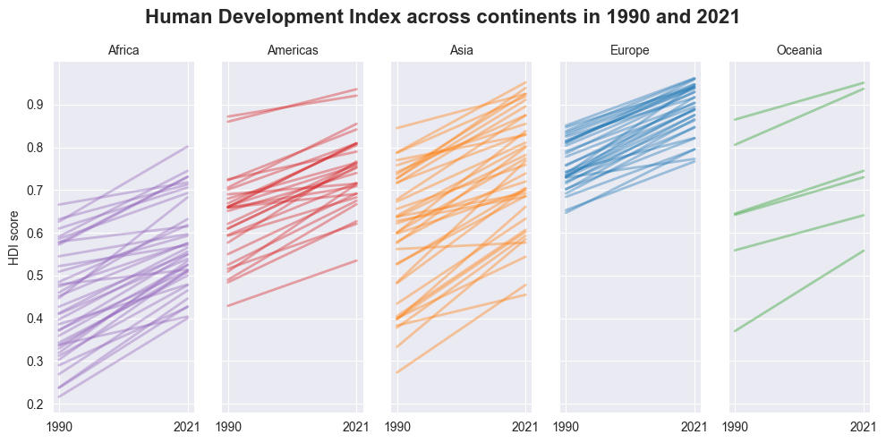

**Hint:**  
Read the documentation for

- `relplot` here: https://seaborn.pydata.org/generated/seaborn.relplot.html
- `lineplot` here: https://seaborn.pydata.org/generated/seaborn.lineplot.html#seaborn.lineplot

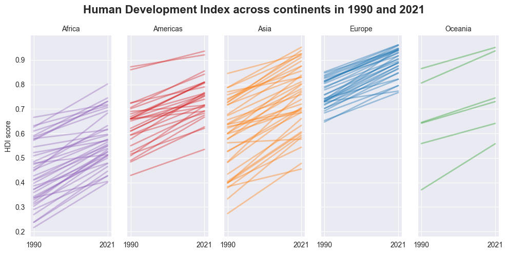

```python
# Type your code here:
g = sns.relplot(
    hdi_regions, x = 'year', y = 'hdi', col = 'Region.Name', hue = 'Region.Name',
    col_order = ['Africa', 'Americas', 'Asia', 'Europe', 'Oceania'],
    kind = 'line', col_wrap = 5, units = 'Country', legend = None,
    estimator = None, alpha = 0.4, linewidth = 2, aspect = 0.4)
g.set_titles('{col_name}')
g.set(xticks = [1990, 2021])
g.set_axis_labels('', 'HDI score')
g.figure.suptitle('Human Development Index across continents in 1990 and 2021',
                  weight = 'bold', fontsize = 16)
plt.tight_layout()
plt.show()
```